# Validation and Evaluation of the scRNA-seq Toolkit on Danio rerio

Comprehensive testing of all analytical functions on red_dr.h5ad

Author

Pablo López Ruiz

# Introduction

This document provides a practical demonstration of key computational methods developed during my Master’s Thesis. Due to confidentiality restrictions, the primary thesis code and work cannot be publicly distributed. This notebook demonstrates the analytical pipeline used in the original single-cell dataset.

The accompanying Python toolkit (`toolkit.py`) provides functions for:

- Quality control and cell preprocessing
- Dimensionality reduction and variance analysis
- Sample and temporal distribution profiling
- Differential expression analysis
- Temporal expression trend modeling
- Z-score computation based on cell-type specific expression trend
- Clustered heatmaps

Furthermore, this work demonstrates:

- Proficiency in Python development
- Deep understanding of single-cell genomics workflows and data structures (AnnData, Scanpy)
- Statistical modeling and hypothesis testing on high-dimensional biological data
- Advanced scientific visualizations

# Analytical Pipeline

## Environment Setup and Module Loading

We import the required scientific libraries and our modular toolkit (`toolkit.py`).

```python
import os
import gc
import numpy as np
import pandas as pd
import scanpy as sc
import matplotlib.pyplot as plt
import toolkit as tk

plt.ioff()

# Apply the publication style defined in the Master's Thesis
tk.apply_tfm_style()

# Global variables
TF_FILE_PATH = "tf.txt"
SUB_FILE_PATH = "tf_cell_types.pkl"
```

## Dataset Loading and Reduction (`red_dr.h5ad`)

In this example we use a *Danio rerio* single-cell developmental study dataset. The following lines correspond to the reduction of the original dataset `dr.h5ad` to generate `red_dr.h5ad`, selecting essential variables from head tissue (*head*) to optimize resource usage. > This dataset comes from [*Duran et. al, 2025* publication](https://cellxgene.cziscience.com/collections/4ea9a90e-1dad-4c67-b1e3-8488ab7dc269)

```python
# adata = sc.read_h5ad("dr.h5ad")
# del adata.obsm
# del adata.uns
# adata.obs = adata.obs[[
#     "Size_Factor",
#     "n.umi",
#     "cell_type_short",
#     "num_genes_expressed",
#     "disease",
#     "tissue",
#     "development_stage"
# ]]
# adata.var = adata.var[[
#     "gene_short_name",
#     "chromosome",
#     "feature_name",
#     "feature_type"
# ]]
# adata = adata[adata.obs.tissue == "head"]
# adata.write_h5ad("red_dr.h5ad")

adata = sc.read_h5ad("red_dr.h5ad")
```

## Temporal Mapping and Danio rerio Specific Annotations

To test the toolkit capabilities, we need to: 1. Map the ontological stages in `development_stage` to a continuous quantitative chronological scale (hours post-fertilization `time_hpf` and days `time_days`), following the standard *Danio rerio* developmental staging series (Kimmel et al., 1995). 2. Identify mitochondrial genes (`is_mt`) and ribosomal genes (`is_ribo`). 3. Annotate zebrafish transcription factor families (`is_tf`) and a subset of these factors (`is_sub`).

We also create the `is_mt` and `is_ribo` columns to identify mitochondrial and ribosomal genes, respectively. Finally, a set of transcription factors and a subset of these are established for downstream analysis.

> Originally we used a subset of transcription factors related to specific developmental stages, but here we use a randomly generated cell-type-specific subset to demonstrate the capabilities of the toolkit without biological significance.

```python
# Change adata.var index from ENSEMBL to gene short name and rm duplicates
adata.var = adata.var.set_index("gene_short_name")
adata = adata[:, ~adata.var.index.duplicated(keep="first")].copy()

# Map developmental stages to quantitative time points
stage_to_hpf = {
    'segmentation:14-19 somites': 18.0,
    'segmentation:20-25 somites': 21.0,
    'segmentation:26+ somites': 24.0,
    'pharyngula:prim-5': 24.0,
    'pharyngula:prim-15': 30.0,
    'pharyngula:prim-25': 36.0,
    'pharyngula:high-pec': 42.0,
    'hatching:long-pec': 48.0,
    'hatching:pec-fin': 60.0,
    'larval:protruding-mouth': 72.0,
}
adata.obs['time_hpf'] = (adata.obs['development_stage']
.map(stage_to_hpf)
.astype(float))
adata.obs['time_days'] = adata.obs['time_hpf'] / 24.0

# Free intermediate mapping dictionary
stage_to_hpf = None
gc.collect()

# Identification of mitochondrial and ribosomal genes
adata.var['is_mt'] = (adata.var.feature_type
.astype(str)
.str.startswith(("Mt", "MT", "mt")))
adata.var['is_ribo'] = (adata.var.feature_type.astype(str) == "rRNA")

# Load transcription factors from a file
tf_set = set()
with open(TF_FILE_PATH) as f:
    for line in f.readlines():
        line = line.strip()
        tf_set.add(line)

tf_set = tf_set.intersection(adata.var.index)

adata.var['is_tf'] = adata.var.index.isin(tf_set)

# Load subset of TFs (just for showing the use of the program)
sub_dict = pd.read_pickle(SUB_FILE_PATH)
sub_set = set().union(*sub_dict.values())
adata.var['is_sub'] = adata.var_names.isin(sub_set)

# Free intermediate set
sub_set = None
gc.collect()
```

```
0
```

## Quality Control and Preprocessing (`qc_and_preprocess`)

We compute cell viability metrics, filter out low-quality cells or those with excessive mitochondrial/ribosomal content, apply library size normalization (10,000 counts), and perform `log1p` transformation.

```python
qc_res = tk.qc_and_preprocess(
    adata,
    mt_col="is_mt",
    ribo_col="is_ribo",
    max_mt_pct=20.0,
    max_ribo_pct=20.0,
    min_genes_per_cell=200,
    min_cells_per_gene=5,
    target_sum=1e4,
    log_transform=True
)

print(f"Filtered cells:\n"
      f"{qc_res['metrics']['n_cells_before']} "
      f"-> {qc_res['metrics']['n_cells_after']}")
print(f"Filtered genes:\n"
      f"{qc_res['metrics']['n_genes_before']} "
      f"-> {qc_res['metrics']['n_genes_after']}")
```

```
Filtered cells:
34325 -> 22019
Filtered genes:
31312 -> 21374
```

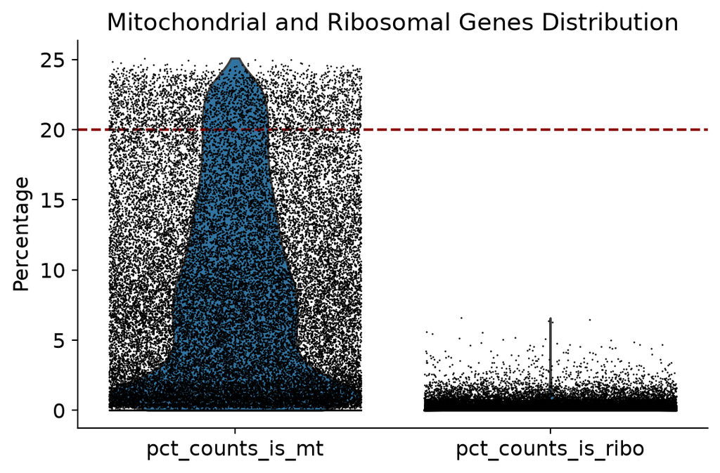

Figure 1: Distribution of mitochondrial and ribosomal gene percentages per cell with quality control thresholds.

```python
qc_res["fig_violin"]
```

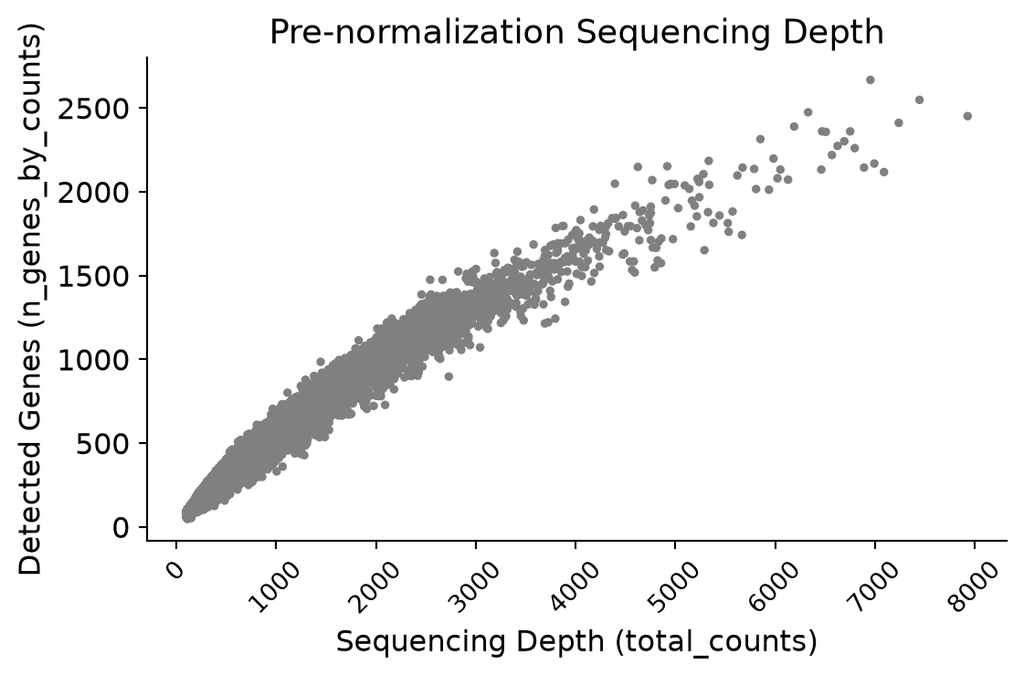

Figure 2: Pre-normalization sequencing depth showing detected genes versus total counts per cell.

```python
qc_res["fig_depth_pre"]
```

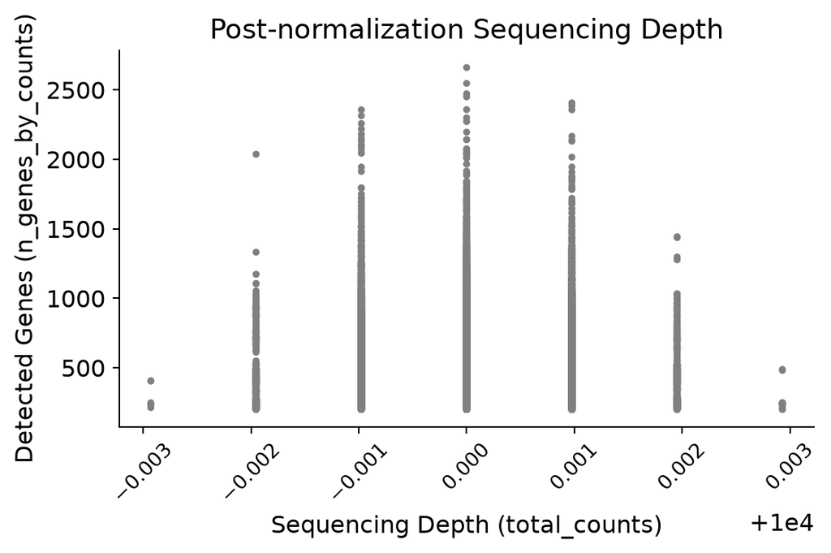

Figure 3: Post-normalization sequencing depth following library size scaling and cell/gene filtering.

```python
qc_res["fig_depth_post"]
```

## Sample Distribution (`plot_sample_distributions`)

We analyze cell counts across developmental days and evaluate cell density curves across cell types.

```python
dist_res = tk.plot_sample_distributions(
    adata,
    disc_key="time_days",
    cont_key="cell_type_short",
    p_inf=5.0,
    p_sup=95.0
)
```

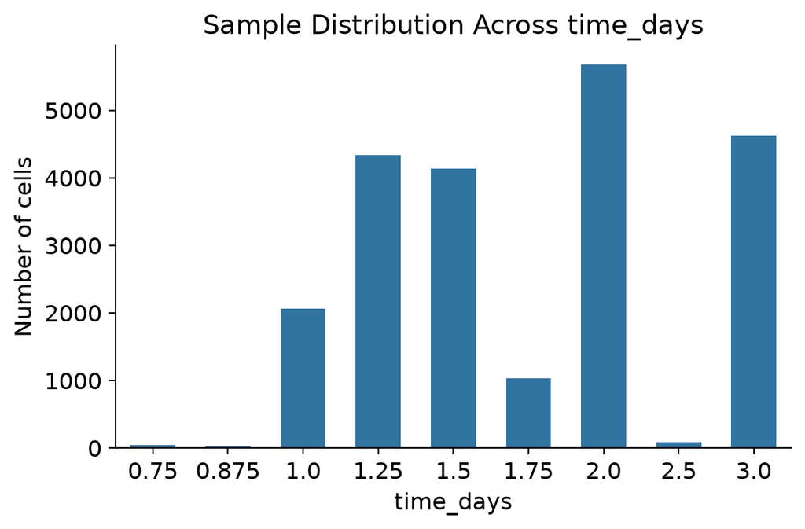

Figure 4: Sample distribution across developmental stages (days post-fertilization).

```python
dist_res['fig_disc']
```

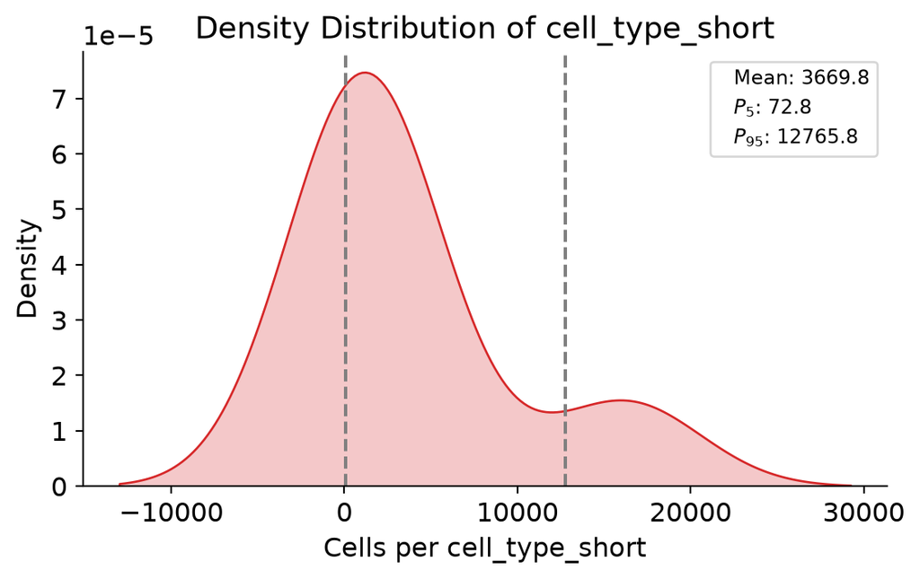

Figure 5: Cell density distribution across cranial cell types, highlighting the mean and bounding percentiles.

```python
dist_res['fig_cont']
```

## Dimensionality Reduction (`compute_dimred`)

We compute PCA (30 components), inspect the variance explained elbow plot, and generate UMAP projections colored by cell type and developmental time.

```python
dimred_res_cell = tk.compute_dimred(
    adata,
    n_pcs=30,
    n_neighbors=15,
    n_components_umap=2,
    color_keys=["cell_type_short"],
    rewrite=False
)

dimred_res_time = tk.compute_dimred(
    adata,
    n_pcs=30,
    n_neighbors=15,
    n_components_umap=2,
    color_keys=["time_days"],
    rewrite=False
)
```

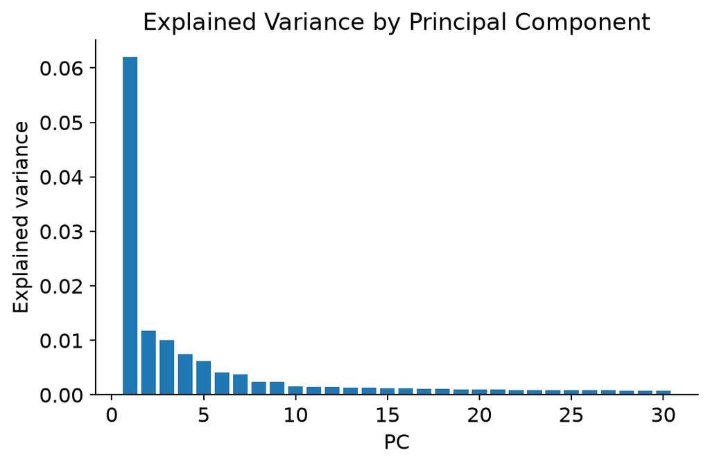

Figure 6: Explained variance ratio per principal component from PCA.

```python
dimred_res_cell['fig_variance']
```

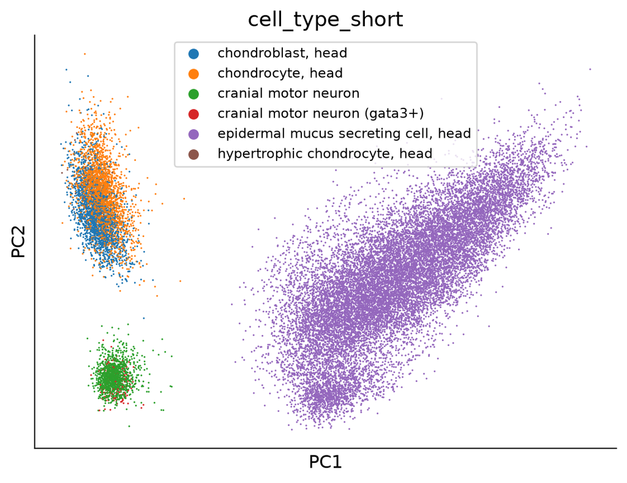

Figure 7: PCA projection of head cells colored by cell type annotation.

```python
dimred_res_cell['fig_pca']
```

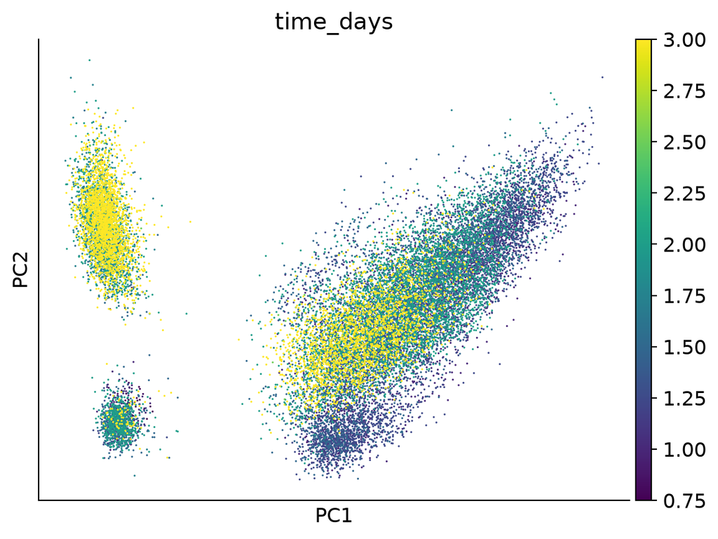

Figure 8: PCA projection of head cells colored by developmental time (days post-fertilization).

```python
dimred_res_time['fig_pca']
```

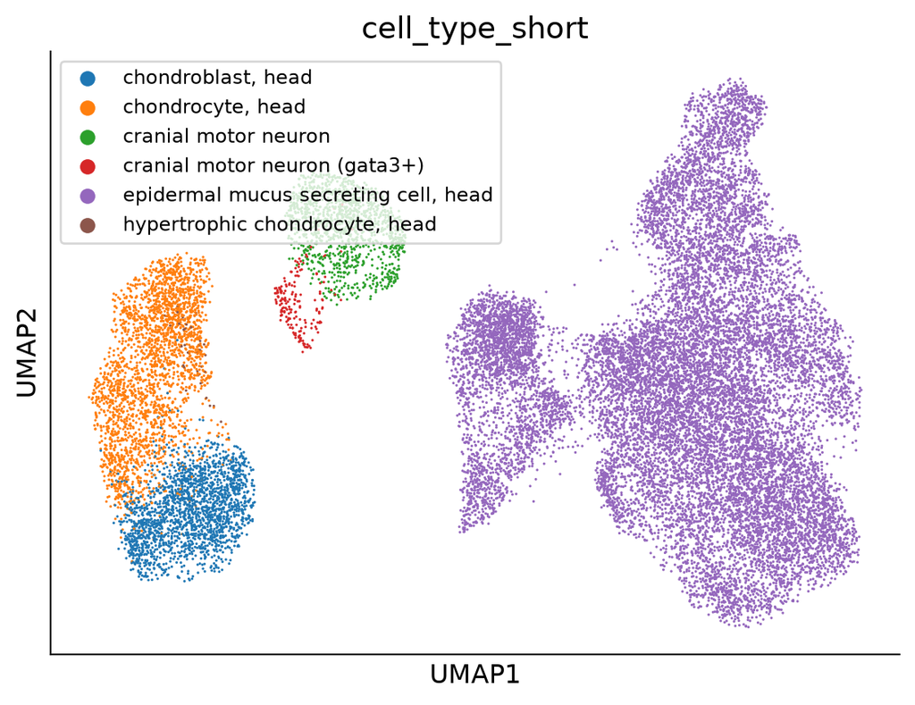

Figure 9: UMAP embedding of single cells colored by distinct cell type populations.

```python
dimred_res_cell['fig_umap']
```

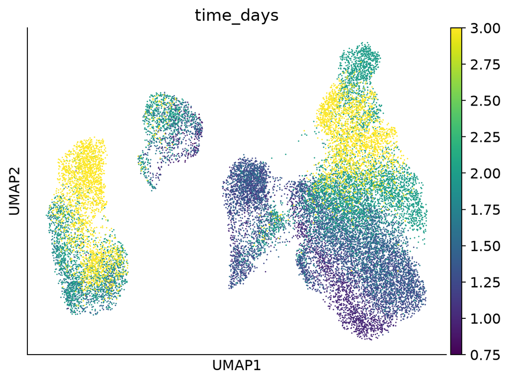

Figure 10: UMAP embedding of single cells colored by developmental progression in days.

```python
dimred_res_time['fig_umap']
```

## Stratified Differential Expression Analysis (`run_stratified_dea`)

We stratify development into two stages (`Late` >= 2.0 days and `Early` < 2.0 days) and evaluate differential expression within each cell type using the Wilcoxon rank-sum test.

```python
adata.obs['age_group'] = np.where(
    adata.obs['time_days'] >= 2.0, 'Late', 'Early'
)

# DEA across the whole transcriptome
dea_res = tk.run_stratified_dea(
    adata,
    grp_key="cell_type_short",
    condition_key="age_group",
    target_group="Late",
    reference_group="Early",
    sel_method="wilcoxon",
    pval_thresh=0.05,
    sub_dict=sub_dict
)

print("Global DEA summary table by cell type:")
dea_res['summary_table']
```

```
Global DEA summary table by cell type:
```

|  | Cell Group | Total Genes | Sig. Genes | Total target | Sig. Target |
| --- | --- | --- | --- | --- | --- |
| 0 | epidermal mucus secreting cell, head | 21374 | 1586 | 9 | 0 |
| 1 | chondrocyte, head | 21374 | 82 | 9 | 0 |
| 2 | chondroblast, head | 21374 | 45 | 8 | 0 |
| 3 | cranial motor neuron | 21374 | 72 | 7 | 0 |
| 4 | cranial motor neuron (gata3+) | 21374 | 17 | 8 | 0 |

```python
# DEA restricted to Transcription Factors
# (recalculates rank_genes_groups and adjusted p-values on the TF subset)
adata_tf = adata[:, adata.var["is_tf"]].copy()

dea_res_tf = tk.run_stratified_dea(
    adata_tf,
    grp_key="cell_type_short",
    condition_key="age_group",
    target_group="Late",
    reference_group="Early",
    sel_method="wilcoxon",
    pval_thresh=0.05,
    sub_dict=sub_dict
)

# Release temporary AnnData copy from memory
adata_tf = None
gc.collect()

print("DEA summary table restricted to Transcription Factors:")
dea_res_tf['summary_table']
```

```
DEA summary table restricted to Transcription Factors:
```

|  | Cell Group | Total Genes | Sig. Genes | Total target | Sig. Target |
| --- | --- | --- | --- | --- | --- |
| 0 | epidermal mucus secreting cell, head | 1236 | 104 | 9 | 0 |
| 1 | chondrocyte, head | 1236 | 13 | 9 | 0 |
| 2 | chondroblast, head | 1236 | 9 | 8 | 0 |
| 3 | cranial motor neuron | 1236 | 5 | 7 | 0 |
| 4 | cranial motor neuron (gata3+) | 1236 | 1 | 8 | 0 |

## Scientific Volcano Plot (`plot_volcano`)

We generate a volcano plot highlighting significance levels for p-values, log2 fold changes, and designated gene categories. Here we focus specifically on cranial motor neurons (`cranial motor neuron`).

```python
celltype = 'cranial motor neuron'
df_volc = dea_res['dea_by_group'][celltype]

volcano_res = tk.plot_volcano(
    df_volc,
    target_genes=sub_dict[celltype],
    pval_col="pvals_adj",
    lfc_col="logfoldchanges",
    gene_label_col="common",
    pval_thresh=0.05,
    lfc_thresh=1.0,
    lfc_highlight_thresh=3.0,
    title=f"Volcano Plot - {celltype} (Late vs Early)",
    figsize=(9, 6)
)

# Release temporary DataFrame slice from memory
df_volc = None
gc.collect()
```

```
69
```

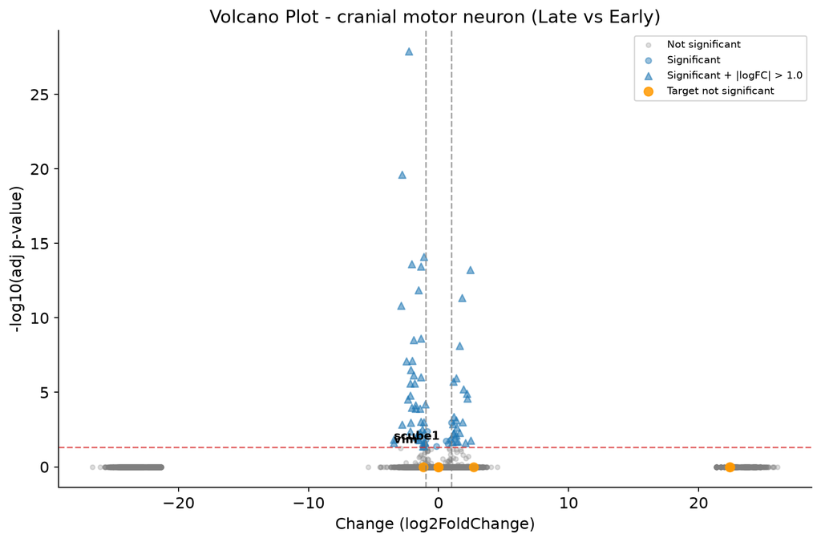

Figure 11: Volcano plot of differential expression for cranial motor neurons (Late vs. Early development), highlighting target transcription factors.

```python
volcano_res['fig']
```

## Temporal Trends in Gene Expression (`compute_temporal_slopes`)

We fit linear regression models for each gene across developmental time, categorizing them into *Target group (subset of TFs)*, *Transcription factors*, and *Rest of genes*.

```python
slopes_res = tk.compute_temporal_slopes(
    adata,
    time_key="time_days",
    min_expressing_cells=10,
    tf_col="is_tf",
    sub_col="is_sub"
)
```

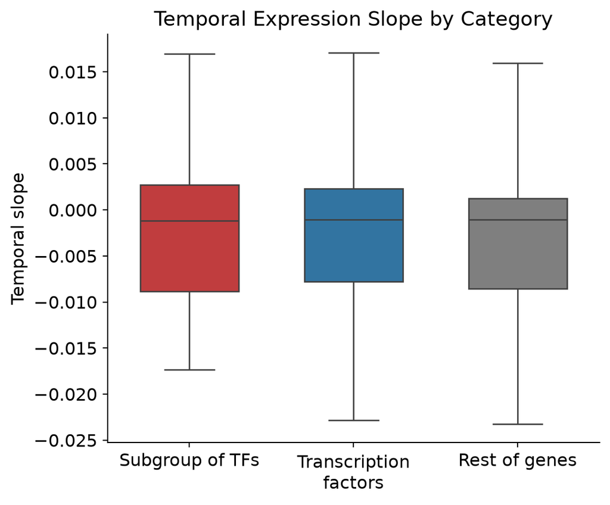

Figure 12: Distribution of temporal expression slopes across gene categories (target TF subset, all transcription factors, and background genes).

```python
slopes_res['fig_boxplot']
```

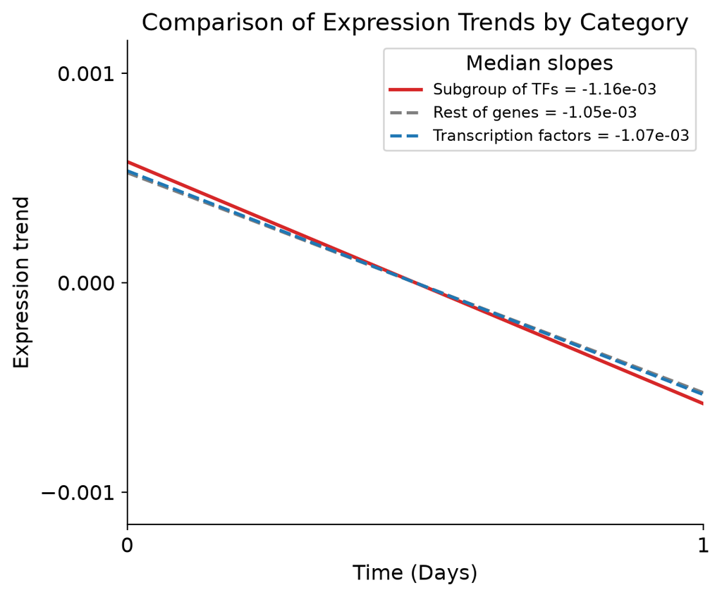

Figure 13: Median linear expression trajectories across developmental days comparing each gene category.

```python
slopes_res['fig_trend']
```

## Hypothesis Testing: Permutation and Mann-Whitney Tests (`run_tests`)

We statistically test whether the temporal slopes of the target transcription factor subset differ significantly from the background gene distribution using 1,000 Monte Carlo permutations and the Mann-Whitney U test.

```python
df_slopes = slopes_res['df_slopes'].dropna(subset=['slope'])

test_res = tk.run_tests(
    col_data=df_slopes['slope'],
    col_cat=df_slopes['cat'],
    sel_cat=tk.SUB_NAME,
    permutation_test=True,
    mannwhitney_test=True,
    n_permutations=1000,
    alternative="two-sided"
)

# Release temporary slopes DataFrame from memory
df_slopes = None
gc.collect()

print(f"Monte Carlo permutation p-value: {test_res['p_perm']}")
print(f"Mann-Whitney U test p-value:     {test_res['p_mw']}")
```

```
Monte Carlo permutation p-value: 0.8781218781218781
Mann-Whitney U test p-value:     0.9047198000781299
```

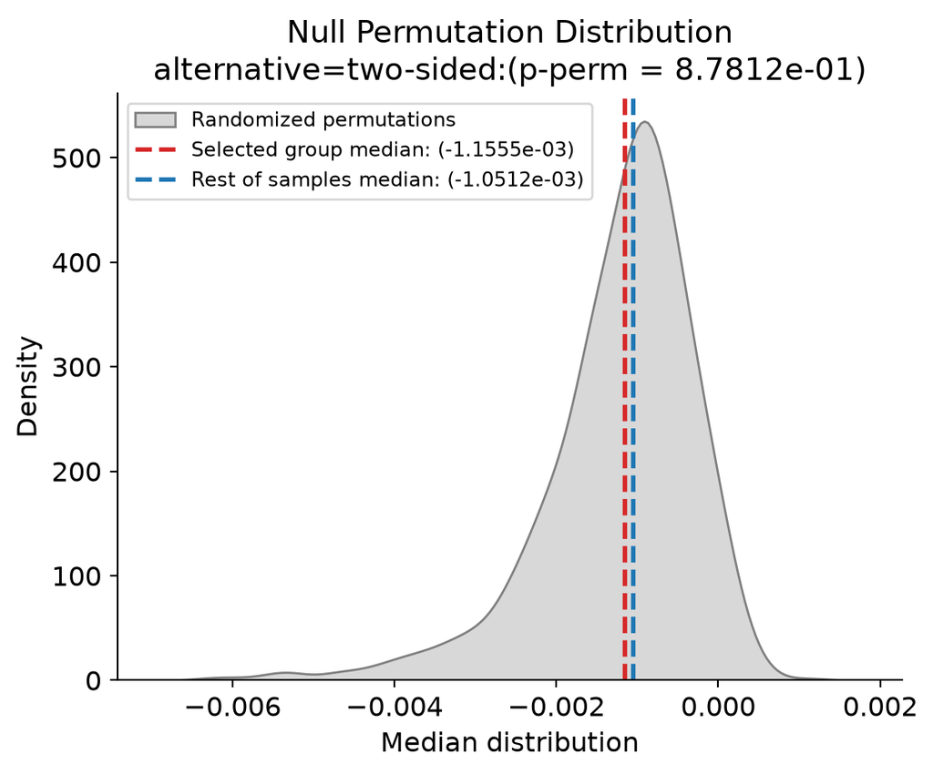

Figure 14: Null permutation distribution of median slopes with empirical cutoffs and observed group medians.

```python
test_res['fig_dist']
```

## Cell-Type Specific Slopes and Z-Scores (`compute_celltype_slopes_and_zscores`)

We compute cell-type-specific temporal expression rates of change within each cell population and standardize them into Z-scores.

```python
ct_slopes_res = tk.compute_celltype_slopes_and_zscores(
    adata,
    celltype_key="cell_type_short",
    time_key="time_days",
    min_expressing_cells=5,
    min_cells=10,
    min_time=2
)
```

## Heatmap with Highlighted Markers (`plot_heatmap_with_highlights`)

```python
df_z = ct_slopes_res['z_scores'].dropna()

heatmap_res = tk.plot_heatmap_with_highlights(
    df=df_z,
    celltype_gene_map=sub_dict,
    subset_genes=list(tf_set)[1000:],
    figsize=(12,12)
)

# Release intermediate z-score matrix and tf_set
df_z = None
tf_set = None
gc.collect()
```

```
21
```

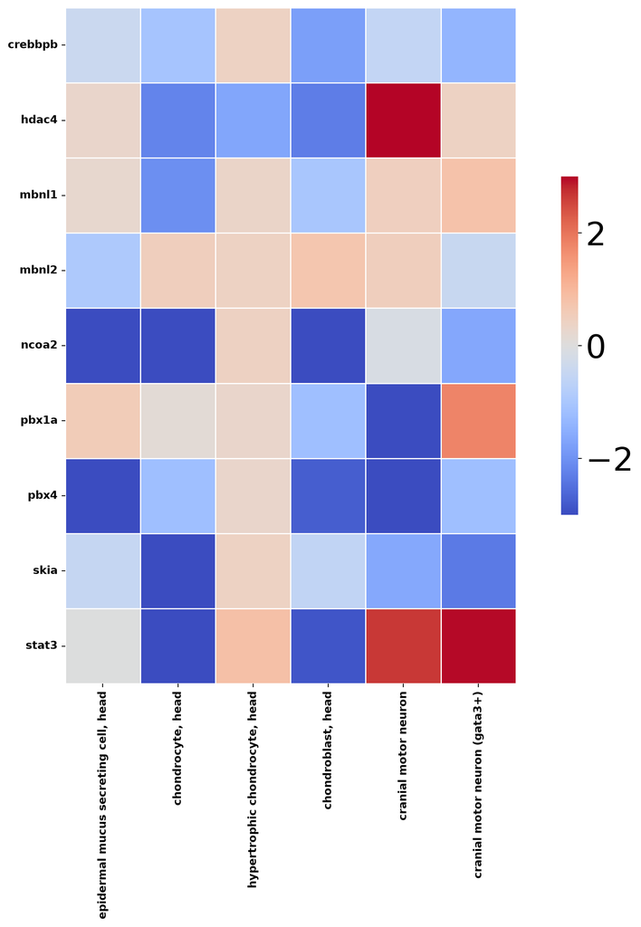

```python
heatmap_res['fig']
```